# Assignment 1

Kevin Patyk

9/27/2021

# Loading the packages that will be used

```r
library(tidyverse)
library(magrittr)
library(DT)
```

# Data import and preliminary examination

```r
sleep_df <- read_csv("Subjective_Sleep_Quality.csv")
```

**Checking the number of observations and the number of variables.**

```r
nrow(sleep_df)
```

```
## [1] 546
```

```r
ncol(sleep_df)
```

```
## [1] 21
```

**Examining the first 6 rows of the data.**

```r
sleep_df %>%
  head()
```

|  | University | Case_Number | Age | Sex | Year_of_Study | Department_Name | MEQ | Trait_Anxiety | Start_time_code | Start_time | PSQI_component_1 | Avg_Weekly_Sleep_Duration | Avg_Sleep_Working_days | Avg_sleep_free_days | Daytime_Dozing | Daytime_Dozing_Groups | Cigarettes_dichotomous | Alcohol_dichotomous | Caffeine_dichotomous | coffee_dichotomous | psqi_2_groups |
| --- | --- | --- | --- | --- | --- | --- | --- | --- | --- | --- | --- | --- | --- | --- | --- | --- | --- | --- | --- | --- | --- |
| 1 | 1 | 1 | 19 | 2 | 2 | Psychology | 15 | 30 | 7 | 12:00:00 | 1 | 6.42 | 5.17 | 9.57 | 4 | 1 | 1 | 1 | 1 | 1 | 1 |
| 2 | 1 | 2 | 18 | 2 | 1 | Psychology | 13 | 50 | 5 | 10:00:00 | 2 | 8.46 | 8.25 | 9 | 6 | 2 | 1 | 2 | 1 | 1 | 2 |
| 3 | 1 | 3 | 19 | 2 | 2 | Psychology | 21 | 32 | 4 | 09:00:00 | 1 | 6.81 | 7.67 | 5.67 | 2 | 1 | 1 | 1 | 1 | 2 | 1 |
| 4 | 1 | 4 | 19 | 2 | 1 | Psychology | 9 | 53 | 6 | 11:00:00 | 1 | 8.61 | 6 | 12.08 | 6 | 2 | 2 | 1 | 1 | 2 | 1 |
| 5 | 1 | 5 | 19 | 2 | 2 | Psychology | 17 | 39 | 5 | 10:00:00 | 1 | 7.88 | 7.33 | 9.25 | 9 | 2 | 1 | 2 | 1 | 2 | 1 |
| 6 | 1 | 6 | 18 | 2 | 1 | Psychology | 5 | 60 | 6 | 11:00:00 | 2 | 7.42 | 5.98 | 11 | 8 | 2 | 1 | 1 | 2 | 2 | 2 |

**Examining the last 6 rows of the data.**

```r
sleep_df %>%
  tail()
```

|  | University | Case_Number | Age | Sex | Year_of_Study | Department_Name | MEQ | Trait_Anxiety | Start_time_code | Start_time | PSQI_component_1 | Avg_Weekly_Sleep_Duration | Avg_Sleep_Working_days | Avg_sleep_free_days | Daytime_Dozing | Daytime_Dozing_Groups | Cigarettes_dichotomous | Alcohol_dichotomous | Caffeine_dichotomous | coffee_dichotomous | psqi_2_groups |
| --- | --- | --- | --- | --- | --- | --- | --- | --- | --- | --- | --- | --- | --- | --- | --- | --- | --- | --- | --- | --- | --- |
| 1 | 1 | 541 | 21 | 2 | 2 | Psychology | 14 | 36 | 4 | 09:00:00 | 1 | 8.43 | 4.5 | 10 | 9 | 2 | 1 | 2 | 1 | 2 | 1 |
| 2 | 1 | 542 | 21 | 1 | 2 | Psychology | 9 | 49 | 5 | 10:00:00 | 2 | 9.56 | 8 | 10.73 | 9 | 2 | 1 | 1 | 1 | 2 | 2 |
| 3 | 1 | 543 | 18 | 2 | 1 | Psychology | 8 | 37 | 7 | 12:00:00 | 1 | 8.67 | 6.17 | 9.67 | 7 | 2 | 1 | 1 | 1 | 2 | 1 |
| 4 | 1 | 544 | 22 | 2 | 2 | Psychology | 13 | 46 | 7 | 12:00:00 | 2 | 8.64 | 8.5 | 9.5 | 10 | 2 | 1 | 1 | 1 | 2 | 2 |
| 5 | 1 | 545 | 19 | 2 | 2 | Psychology | 14 | 37 | 6 | 11:00:00 | 1 | 5.2 | 4.48 | 9.5 | 6 | 2 | 1 | 1 | 1 | 2 | 1 |
| 6 | 1 | 546 | 19 | 2 | 1 | Psychology | 14 | 54 | 7 | 12:00:00 | 2 | 7.03 | 5.07 | 7.82 | 15 | 4 | 1 | 2 | 2 | 2 | 2 |

**Examining the structure of the data and data types.**

```r
str(sleep_df)
```

[output not shown]

**The variables `Department_Name`, `Year_of_Study`, `Sex`, and the other dichotomous variables need to be converted to a factors.**

```r
sleep_df %<>%
  mutate(Department_Name = as.factor(Department_Name),
         Year_of_Study = as.factor(Year_of_Study),
         Sex = as.factor(Sex),
         coffee_dichotomous = as.factor(coffee_dichotomous),
         Cigarettes_dichotomous = as.factor(Cigarettes_dichotomous),
         Alcohol_dichotomous = as.factor(Alcohol_dichotomous),
         Caffeine_dichotomous = as.factor(Caffeine_dichotomous),
         coffee_dichotomous = as.factor(coffee_dichotomous))
```

# Obtaining descriptive statistics and frequencies for categorical/dichotomous variables

**Obtaining the mean and standard deviation for age.**

```r
sleep_df %$%
  mean(Age)
```

```
## [1] 20.40842
```

```r
sleep_df %$%
  sd(Age)
```

```
## [1] 4.306155
```

**Getting a table of how many students are there per each department.**

```r
sleep_df %$%
  table(Department_Name)
```

|  | Department_Name | Freq |
| --- | --- | --- |
| 1 | Psychology | 486 |
| 2 | Other | 20 |
| 3 | Life Sciences | 17 |
| 4 | Social Sciences | 15 |
| 5 | Business School | 3 |
| 6 | English and Cre | 2 |
| 7 | Dance | 1 |
| 8 | Drama | 1 |
| 9 | Media, Culture | 1 |

**Getting a table of sex.**

```r
#1 = male, 2 = female
sleep_df %$%
  table(Sex)
```

```
## Sex
##   1   2
##  85 461
```

**Getting a table of how many students are in each year of study.**

```r
sleep_df %$%
  table(Year_of_Study)
```

```
## Year_of_Study
##   1   2   3
## 291 225  30
```

**Getting a table of tobacco consumption.**

```r
#1 = smoker, 2 = non-smoker
sleep_df %$%
  table(Cigarettes_dichotomous)
```

```
## Cigarettes_dichotomous
##   1   2
## 466  80
```

**Getting a table of caffeine consumption.**

```r
#1 = consumes caffeine, 2 = does not consume caffeine
sleep_df %$%
  table(Caffeine_dichotomous)
```

```
## Caffeine_dichotomous
##   1   2
## 327 219
```

**Getting a table of alcohol consumption.**

```r
#1 = consumes alcohol, 2 = does not consume alcohol
sleep_df %$%
  table(Alcohol_dichotomous)
```

```
## Alcohol_dichotomous
##   1   2
## 260 286
```

**Getting a table of coffee consumption.**

```r
#1 = consumes coffe, 2 = does not consume coffee
sleep_df %$%
  table(coffee_dichotomous)
```

```
## coffee_dichotomous
##   1   2
##  65 481
```

# Exploratory data analysis part 1: Exploring general sleeping trends

**Getting descriptive statistics for sleep duration.**

```r
#need to make a function to obtain means and standard deviations quickly
DescriptiveStatistics <- function(x) {
  Mean <- round(mean(x), digits = 2)
  Standard_Deviation <- round(sd(x), digits = 2)
  return(c(Mean = Mean, Standard_Deviation = Standard_Deviation))
}
```

```r
#running the function over our sleep duration variables of interest
desc_stats_sleep <- sapply(X = sleep_df[, c(12, 13, 14)], FUN = DescriptiveStatistics)
```

|  | Mean | Standard_Deviation |
| --- | --- | --- |
| Avg_Weekly_Sleep_Duration | 7.49 | 1.39 |
| Avg_Sleep_Working_days | 6.55 | 1.5 |
| Avg_sleep_free_days | 8.8 | 1.61 |

**Examining a histogram of average weekly sleep duration.**

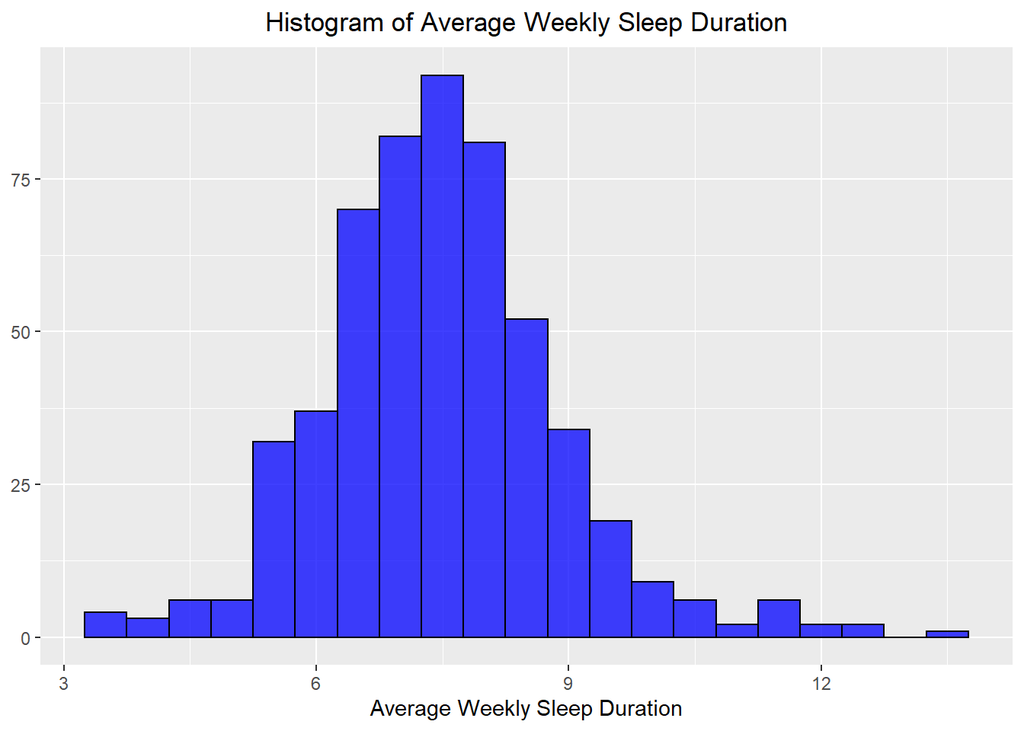

```r
sleep_df %>%
  ggplot(aes(x = Avg_Weekly_Sleep_Duration)) +
  geom_histogram(binwidth = .5, color = "black", fill = "blue", alpha = .75) +
  xlab(label = "Average Weekly Sleep Duration") +
  ggtitle(label = "Histogram of Average Weekly Sleep Duration") +
  theme(axis.title.y = element_blank()) +
  theme(plot.title = element_text(hjust = 0.5))
```

**Examining a histogram of average sleep duration on working days.**

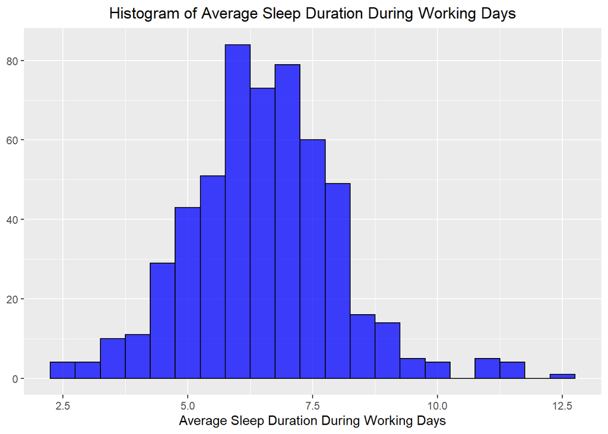

```r
sleep_df %>%
  ggplot(aes(x = Avg_Sleep_Working_days)) +
  geom_histogram(binwidth = .5, color = "black", fill = "blue", alpha = .75) +
  xlab(label = "Average Sleep Duration During Working Days") +
  ggtitle(label = "Histogram of Average Sleep Duration During Working Days") +
  theme(axis.title.y = element_blank()) +
  theme(plot.title = element_text(hjust = 0.5))
```

**Examining a histogram of average sleep duration on free days.**

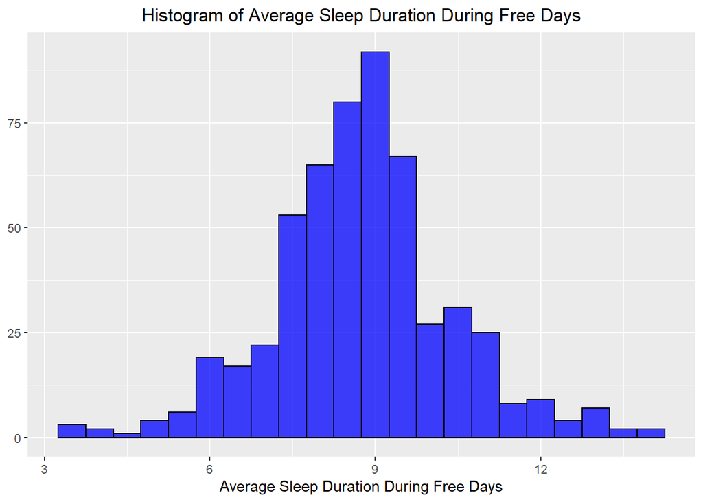

```r
sleep_df %>%
  ggplot(aes(x = Avg_sleep_free_days)) +
  geom_histogram(binwidth = .5, color = "black", fill = "blue", alpha = .75) +
  xlab(label = "Average Sleep Duration During Free Days") +
  ggtitle(label = "Histogram of Average Sleep Duration During Free Days") +
  theme(axis.title.y = element_blank()) +
  theme(plot.title = element_text(hjust = 0.5))
```

**Examining the relationships between average weekly sleep duration, average sleep duration during working days, and average sleep duration during free days.**

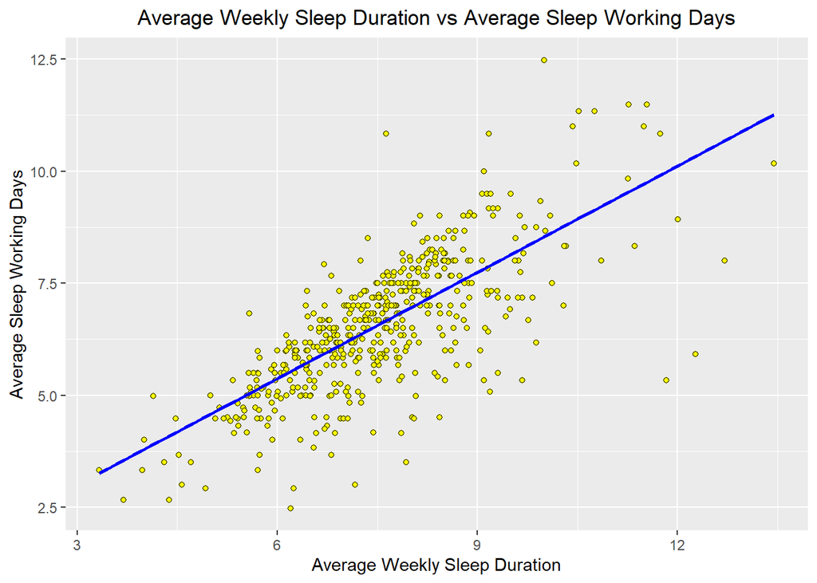

```r
#average weekly sleep duration vs average sleep working days
sleep_df %>%
  ggplot(aes(x = Avg_Weekly_Sleep_Duration, y = Avg_Sleep_Working_days)) +
  geom_point(color = "black", shape = 21, fill = "yellow") +
  geom_smooth(method = "lm", fill = NA, color = "blue") +
  xlab("Average Weekly Sleep Duration") +
  ylab("Average Sleep Working Days") +
  ggtitle("Average Weekly Sleep Duration vs Average Sleep Working Days") +
  theme(plot.title = element_text(hjust = 0.5))
```

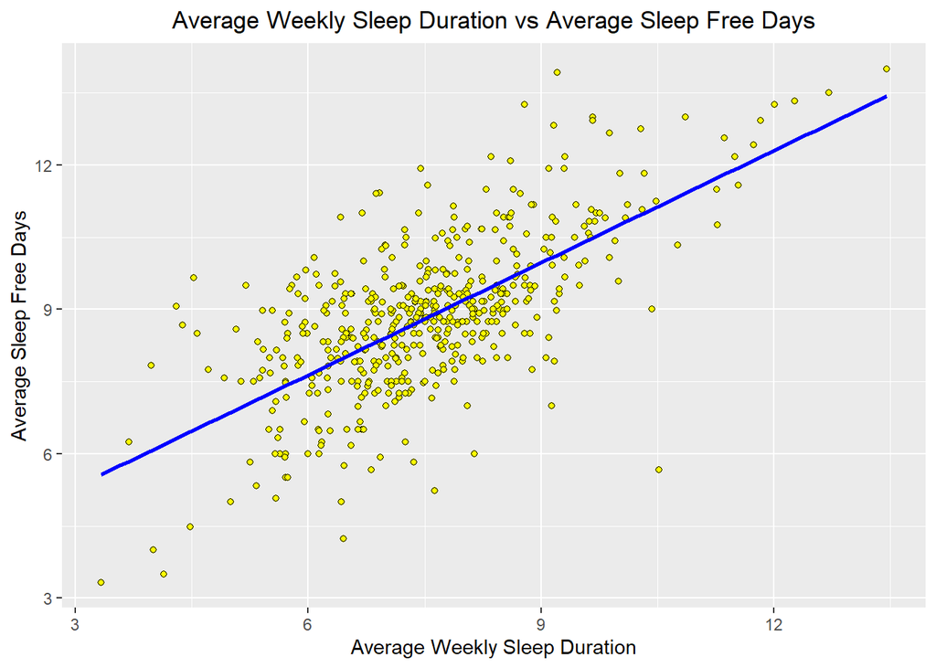

```r
#average weekly sleep duration vs average sleep during free days
sleep_df %>%
  ggplot(aes(x = Avg_Weekly_Sleep_Duration, y = Avg_sleep_free_days)) +
  geom_point(color = "black", shape = 21, fill = "yellow") +
  geom_smooth(method = "lm", fill = NA, color = "blue") +
  xlab("Average Weekly Sleep Duration") +
  ylab("Average Sleep Free Days") +
  ggtitle("Average Weekly Sleep Duration vs Average Sleep Free Days") +
  theme(plot.title = element_text(hjust = 0.5))
```

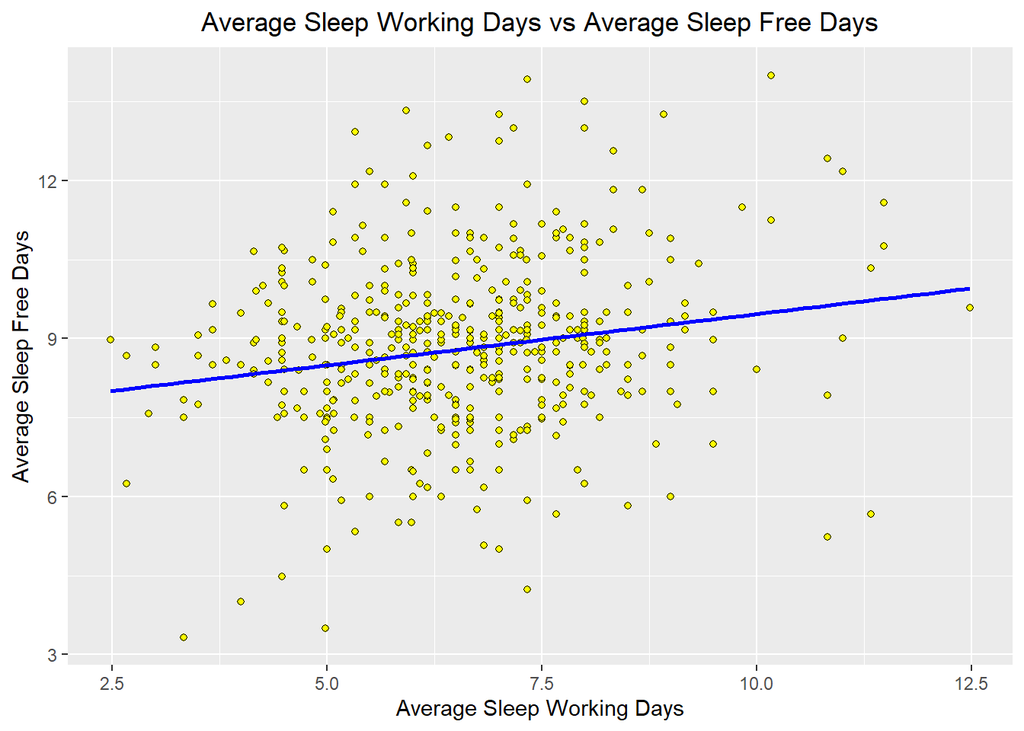

```r
#average sleep duration working days vs average sleep during free days
sleep_df %>%
  ggplot(aes(x = Avg_Sleep_Working_days, y = Avg_sleep_free_days)) +
  geom_point(color = "black", shape = 21, fill = "yellow") +
  geom_smooth(method = "lm", fill = NA, color = "blue") +
  xlab("Average Sleep Working Days") +
  ylab("Average Sleep Free Days") +
  ggtitle("Average Sleep Working Days vs Average Sleep Free Days") +
  theme(plot.title = element_text(hjust = 0.5))
```

## Conclusions from this section:

I wanted to get an idea of the average sleep duration that students within the study are getting on average per week, during working days, and during free days. More specifically, I was curious about the differences during working and free days, since, for students, the difference between the two, I thought, would be substantial. The mean average weekly sleep duration across all students is 7.49 (SD = 1.39). The mean average sleep duration during working days is 6.55 (SD = 1.5). The mean average sleep duration during free days is 8.8 (SD = 1.61). This makes sense, as students throughout the week need to be up for classes and can spend less time sleeping than on off days. I also made histograms for these variables of interest because I wanted to check the distributions and if there were any outliers. Some outliers were found, with some students having an average weekly sleep duration of 12 of hours more. For average sleep during working days, some students slept, on average, 10 hours with one student sleeping 12. For average sleep duration during free days, I excpected the histogram to shift right, as people would be sleeping more then; there were still outliers, with some students sleeping, on average, over 12 hours on free days.

Lastly, I examined the relationships between the average weekly sleep, average sleep duration during work days, and average sleep duration during free days. The scatterplots showed that average weekly sleep had a positive relationship with average sleep during work and free days, which makes sense, since the more you sleep on both types of days, the higher your average sleep. However, I expected that the relationship between average sleep work days and average sleep free days would be negative, since if a student slept less on the work days, then they would sleep more during free days. However, this was not the case as the relationship was still positive.

# Exploratory data analysis part 2: Exploring sleeping trends, substance use, and anxiety

**Checking the weekly average sleep duration based on cigarette use.**

```r
sleep_df %>%
  group_by(Cigarettes_dichotomous) %>%
  summarise(Avg_Weekly_Sleep_Duration = round(mean(Avg_Weekly_Sleep_Duration), digits = 2)) %>%
  arrange(-Avg_Weekly_Sleep_Duration)
```

```
## # A tibble: 2 x 2
##   Cigarettes_dichotomous Avg_Weekly_Sleep_Duration
##   <fct>                                      <dbl>
## 1 2                                           7.71
## 2 1                                           7.45
```

**Checking the weekly average sleep duration based on alcohol use.**

```r
sleep_df %>%
  group_by(Alcohol_dichotomous) %>%
  summarise(Avg_Weekly_Sleep_Duration = round(mean(Avg_Weekly_Sleep_Duration), digits = 2)) %>%
  arrange(-Avg_Weekly_Sleep_Duration)
```

```
## # A tibble: 2 x 2
##   Alcohol_dichotomous Avg_Weekly_Sleep_Duration
##   <fct>                                   <dbl>
## 1 1                                        7.66
## 2 2                                        7.34
```

**Checking the weekly average sleep duration based on caffeine use.**

```r
sleep_df %>%
  group_by(Caffeine_dichotomous) %>%
  summarise(Avg_Weekly_Sleep_Duration = round(mean(Avg_Weekly_Sleep_Duration), digits = 2)) %>%
  arrange(-Avg_Weekly_Sleep_Duration)
```

```
## # A tibble: 2 x 2
##   Caffeine_dichotomous Avg_Weekly_Sleep_Duration
##   <fct>                                    <dbl>
## 1 2                                         7.62
## 2 1                                         7.4
```

**Checking the weekly average sleep duration based on coffee use.**

```r
sleep_df %>%
  group_by(coffee_dichotomous) %>%
  summarise(Avg_Weekly_Sleep_Duration = round(mean(Avg_Weekly_Sleep_Duration), digits = 2)) %>%
  arrange(-Avg_Weekly_Sleep_Duration)
```

```
## # A tibble: 2 x 2
##   coffee_dichotomous Avg_Weekly_Sleep_Duration
##   <fct>                                  <dbl>
## 1 1                                       7.58
## 2 2                                       7.48
```

**Examining cigarette smoking and anxiety levels via boxplot.**

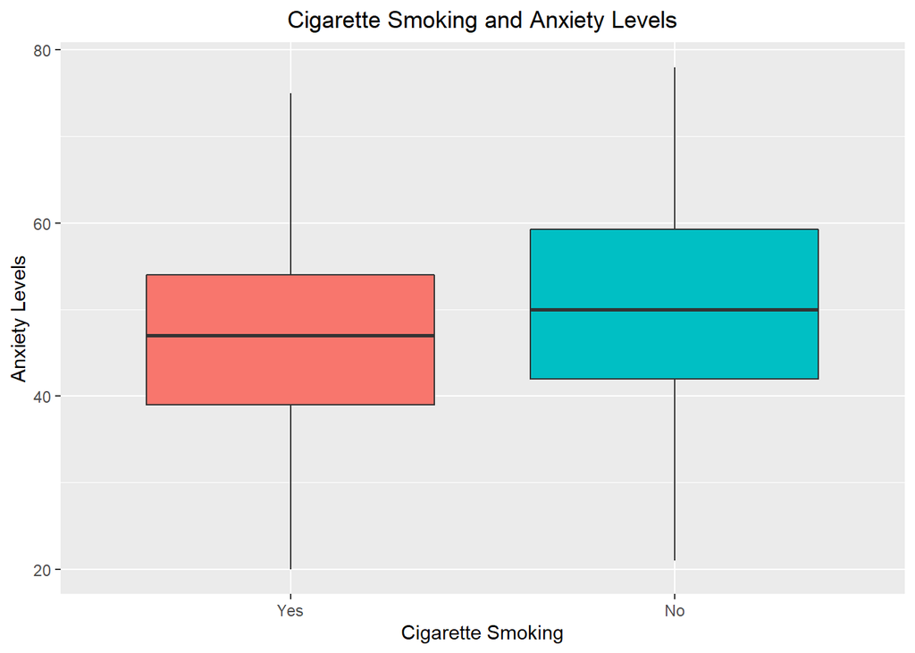

```r
sleep_df %>%
  ggplot(aes(x = Cigarettes_dichotomous, y = Trait_Anxiety)) +
  geom_boxplot(outlier.colour = NA, aes(fill = Cigarettes_dichotomous), show.legend = F) +
  ylab("Anxiety Levels") +
  xlab("Cigarette Smoking") +
  scale_x_discrete(labels = c("Yes", "No")) +
  ggtitle("Cigarette Smoking and Anxiety Levels") +
  theme(plot.title = element_text(hjust = 0.5))
```

**Examining alcohol use and anxiety levels via boxplot.**

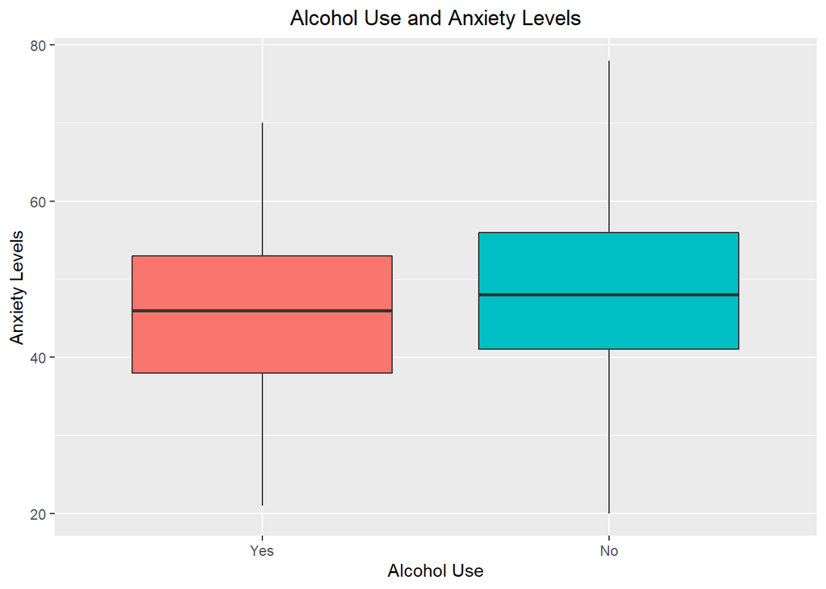

```r
sleep_df %>%
  ggplot(aes(x = Alcohol_dichotomous, y = Trait_Anxiety)) +
  geom_boxplot(outlier.colour = NA, aes(fill = Alcohol_dichotomous), show.legend = F) +
  ylab("Anxiety Levels") +
  xlab("Alcohol Use") +
  scale_x_discrete(labels = c("Yes", "No")) +
  ggtitle("Alcohol Use and Anxiety Levels") +
  theme(plot.title = element_text(hjust = 0.5))
```

**Examining caffeine use and anxiety levels via boxplot.**

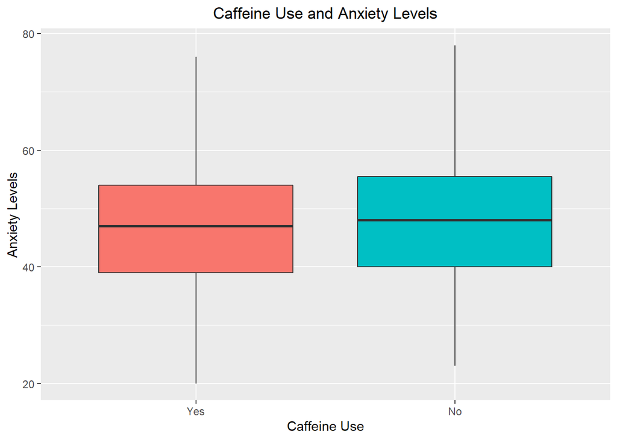

```r
sleep_df %>%
  ggplot(aes(x = Caffeine_dichotomous, y = Trait_Anxiety)) +
  geom_boxplot(outlier.colour = NA, aes(fill = Caffeine_dichotomous), show.legend = F) +
  ylab("Anxiety Levels") +
  xlab("Caffeine Use") +
  scale_x_discrete(labels = c("Yes", "No")) +
  ggtitle("Caffeine Use and Anxiety Levels") +
  theme(plot.title = element_text(hjust = 0.5))
```

**Examining coffee use and anxiety levels via boxplot.**

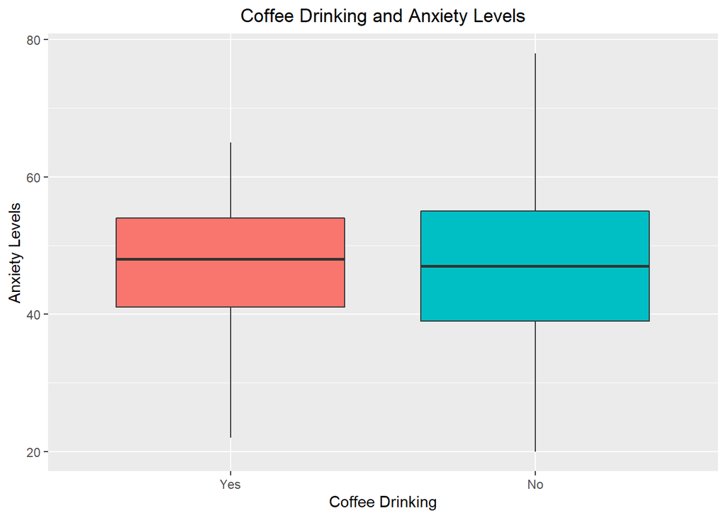

```r
sleep_df %>%
  ggplot(aes(x = coffee_dichotomous, y = Trait_Anxiety)) +
  geom_boxplot(outlier.colour = NA, aes(fill = coffee_dichotomous), show.legend = F) +
  ylab("Anxiety Levels") +
  xlab("Coffee Drinking") +
  scale_x_discrete(labels = c("Yes", "No")) +
  ggtitle("Coffee Drinking and Anxiety Levels") +
  theme(plot.title = element_text(hjust = 0.5))
```

**Examining gender and anxiety levels via boxplot.**

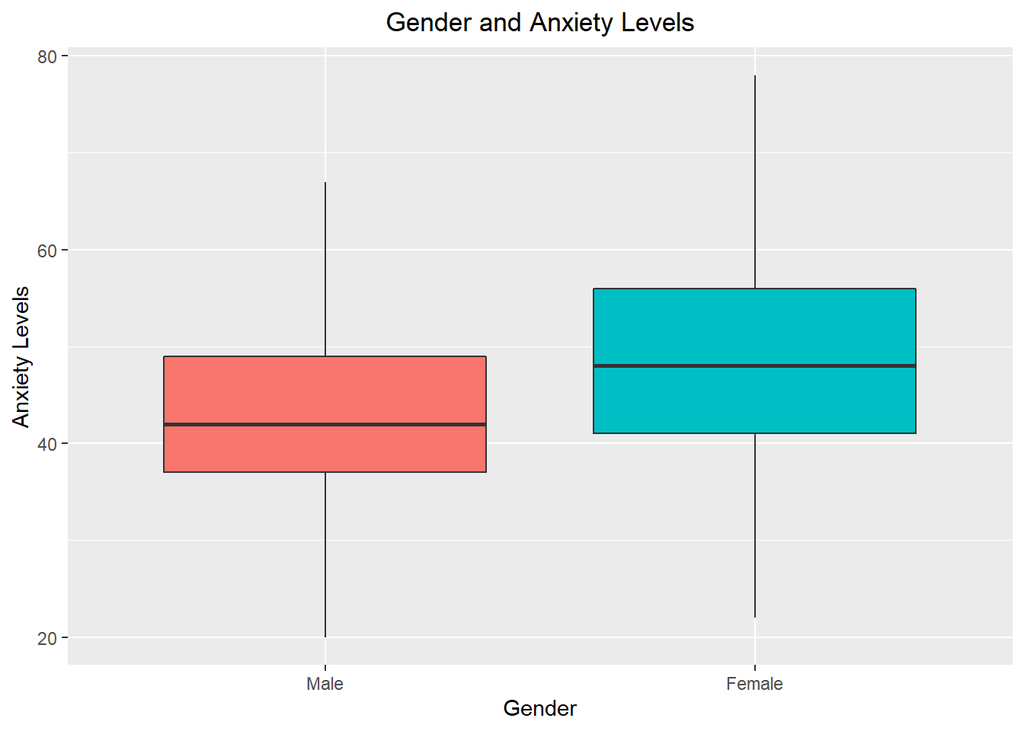

```r
sleep_df %>%
  ggplot(aes(x = Sex, y = Trait_Anxiety)) +
  geom_boxplot(outlier.colour = NA, aes(fill = Sex), show.legend = F) +
  ylab("Anxiety Levels") +
  xlab("Gender") +
  scale_x_discrete(labels = c("Male", "Female")) +
  ggtitle("Gender and Anxiety Levels") +
  theme(plot.title = element_text(hjust = 0.5))
```

## Conclusions from this section:

In this section, I wanted to get more of an idea about average weekly sleep duration, substance use, and anxiety. This is because substance use typically does have an affect on length and quality of sleep and because it can also affect anxiety levels. Lastly, I wanted to look at the difference in anxiety levels between genders because gender can have an affect on anxiety levels. The results show that those who do not smoke cigarettes have a higher average weekly sleep duration, alcohol users have a higher average weekly sleep duration, caffeine users have a lower average weekly sleep duration, and that coffee drinkers have a higher average sleep duration, but not by much. Regarding anxiety levels and substance use, smokers appear to have less anxiety than non-smokers, those who consume alcohol have less anxiety than those who do not, caffeine users and caffeine non-users have almost the same amount of anxiety, and coffee drinkers have a little bit more anxiety than those who do not consume coffee. Lastly, females tend to have far more anxiety than males.

# Exploratory data analysis part 3: Exploring sleeping trends and anxiety within departments and across years

**Checking the average weekly sleep duration per department.**

```r
sleep_df %>%
  group_by(Department_Name) %>%
  summarise(Avg_Wk_Sleep_Dep = round(mean(Avg_Weekly_Sleep_Duration), digits = 2)) %>%
  arrange(-Avg_Wk_Sleep_Dep)
```

|  | Department_Name | Avg_Wk_Sleep_Dep |
| --- | --- | --- |
| 1 | Business School | 7.99 |
| 2 | Dance | 7.67 |
| 3 | Psychology | 7.52 |
| 4 | Life Sciences | 7.51 |
| 5 | English and Cre | 7.44 |
| 6 | Drama | 7.4 |
| 7 | Social Sciences | 7.24 |
| 8 | Other | 6.97 |
| 9 | Media, Culture | 6.81 |

**Checking the average sleep duration during working days per department.**

```r
sleep_df %>%
  group_by(Department_Name) %>%
  summarise(Avg_Sleep_Work_Dep = round(mean(Avg_Sleep_Working_days), digits = 2)) %>%
  arrange(-Avg_Sleep_Work_Dep)
```

|  | Department_Name | Avg_Sleep_Work_Dep |
| --- | --- | --- |
| 1 | Dance | 7 |
| 2 | Drama | 6.83 |
| 3 | Business School | 6.7 |
| 4 | English and Cre | 6.66 |
| 5 | Psychology | 6.57 |
| 6 | Social Sciences | 6.54 |
| 7 | Life Sciences | 6.37 |
| 8 | Other | 6.26 |
| 9 | Media, Culture | 5 |

**Checking the average sleep duration during free days per department.**

```r
sleep_df %>%
  group_by(Department_Name) %>%
  summarise(Avg_Sleep_Free_Dep = round(mean(Avg_sleep_free_days), digits = 2)) %>%
  arrange(-Avg_Sleep_Free_Dep)
```

|  | Department_Name | Avg_Sleep_Free_Dep |
| --- | --- | --- |
| 1 | Dance | 9.33 |
| 2 | Media, Culture | 9.23 |
| 3 | Life Sciences | 9.16 |
| 4 | English and Cre | 8.91 |
| 5 | Business School | 8.86 |
| 6 | Other | 8.86 |
| 7 | Drama | 8.83 |
| 8 | Psychology | 8.8 |
| 9 | Social Sciences | 8.14 |

**Checking the average weekly sleep duration for year of study.**

```r
sleep_df %>%
  group_by(Year_of_Study) %>%
  summarise(Avg_Seep_Week_Yr = round(mean(Avg_Weekly_Sleep_Duration), digits = 2)) %>%
  arrange(-Avg_Seep_Week_Yr)
```

[output not shown]

**Checking the average sleep duration during work days for year of study.**

```r
sleep_df %>%
  group_by(Year_of_Study) %>%
  summarise(Avg_Sleep_Work_Yr = round(mean(Avg_Sleep_Working_days), digits = 2)) %>%
  arrange(-Avg_Sleep_Work_Yr)
```

|  | Year_of_Study | Avg_Sleep_Work_Yr |
| --- | --- | --- |
| 1 | 2 | 6.75 |
| 2 | 3 | 6.53 |
| 3 | 1 | 6.4 |

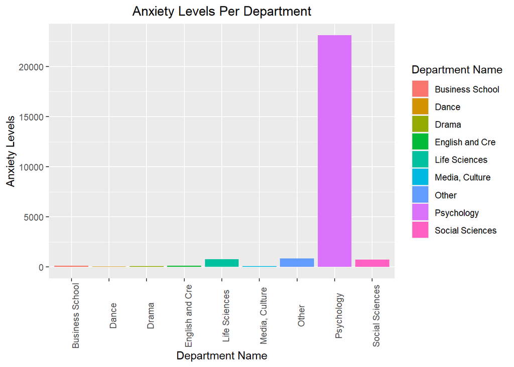

```r
sleep_df %>%
  ggplot(aes(x = Department_Name, y = Trait_Anxiety)) +
  geom_bar(stat = "identity", aes(fill = Department_Name)) +
  ggtitle("Anxiety Levels Per Department") +
  xlab("Department Name") +
  ylab("Anxiety Levels") +
  guides(fill=guide_legend(title="Department Name")) +
  theme(axis.text.x = element_text(angle = 90)) +
  theme(plot.title = element_text(hjust = 0.5))
```

**Checking the anxiety levels between students in different years of study.**

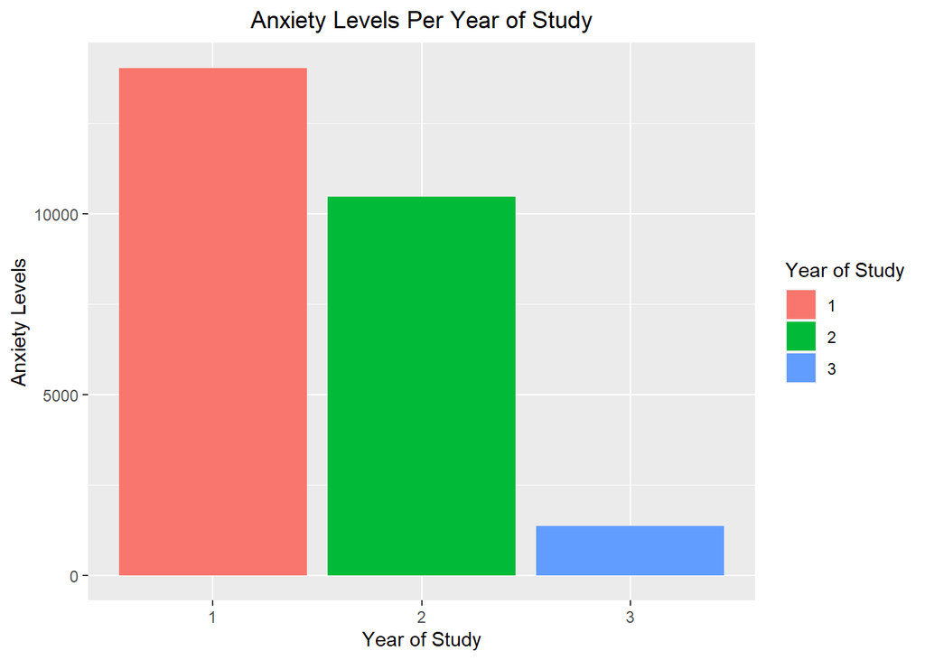

```r
sleep_df %>%
  ggplot(aes(x = Year_of_Study, y = Trait_Anxiety)) +
  geom_bar(stat = "identity", aes(fill = Year_of_Study)) +
  ggtitle("Anxiety Levels Per Year of Study") +
  xlab("Year of Study") +
  ylab("Anxiety Levels") +
  guides(fill=guide_legend(title="Year of Study")) +
  theme(plot.title = element_text(hjust = 0.5))
```

# References

Norbury, R., & Evans, S. (2019). *Time to think: Subjective sleep quality, trait anxiety and university start time*. Psychiatry research, 271, 214-219.

[figure not shown]